# Lab1

Andrew Laws

9/16/2021

# Task 1: Basic data manipulation

### 1.1

```r
#create new df
task1.1 <- d.counties %>% group_by(STATEFP10) %>% #group variables by state and mutate column that holds state area
  mutate(stateArea = sum(ALAND10 + AWATER10)) %>% #mutate column that divides land area by state area
  ungroup(.) %>%
  mutate(perLandAreaState = ALAND10/stateArea * 100) #create percentage variable by dividing land by state area and multiplying by 100

glimpse(task1.1$perLandAreaState)
```

```
##  num [1:207] 0.0342 0.0502 0.0224 0.0208 2.2555 ...
```

### 1.2

```r
#group by state, find max of awater10/state area using slice
task1.2 <- task1.1 %>% as_tibble() %>%
  group_by(STATEFP10) %>%
  mutate(perWaterAreaState = AWATER10/stateArea * 100) %>%
  slice(which.max(perWaterAreaState))

#create df with only state and county name columns
task1.2 <- task1.2 %>% ungroup() %>%
  dplyr::select(STATEFP10, NAMELSAD10)

task1.2
```

```
## # A tibble: 7 x 2
##   STATEFP10 NAMELSAD10
##   <chr>     <chr>
## 1 10        Sussex County
## 2 11        District of Columbia
## 3 24        Dorchester County
## 4 36        Cayuga County
## 5 42        Lancaster County
## 6 51        Accomack County
## 7 54        Greenbrier County
```

### 1.3

```r
#Use count function
task1.3 <- d.counties %>% as_tibble %>%
  count(STATEFP10)
task1.3
```

```
## # A tibble: 7 x 2
##   STATEFP10     n
##   <chr>     <int>
## 1 10            3
## 2 11            1
## 3 24           24
## 4 36           20
## 5 42           43
## 6 51          102
## 7 54           14
```

### 1.4

```r
#use mutate function to create new column with character length
task1.4 <- d.stations %>% as_tibble() %>%
  mutate(., stNameLen = nchar(STATION_NA)) %>%
  slice(which.min(stNameLen)) %>% #slice out the row with the min number of characters
  dplyr::select(STATION_NA) #retain only station name

task1.4
```

```
## # A tibble: 1 x 1
##   STATION_NA
##   <chr>
## 1 ABRAM CREEK AT OAKMONT, WV
```

# Task 2: Plotting attribute data

### 2.1

[figure not shown]

### 2.2

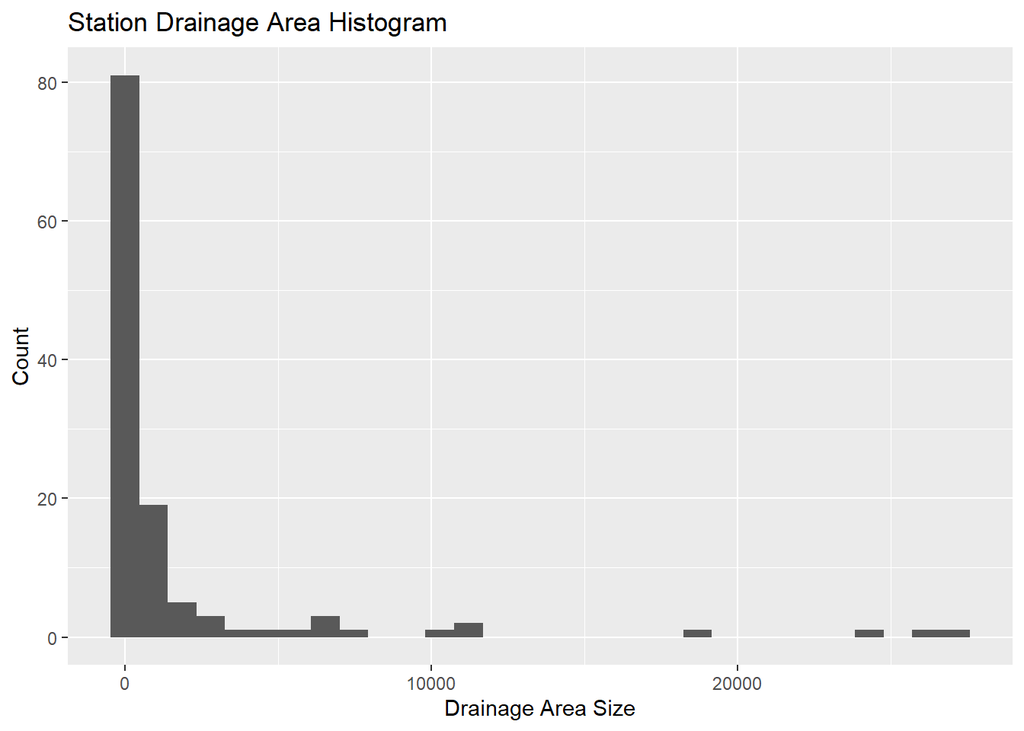

### 2.3

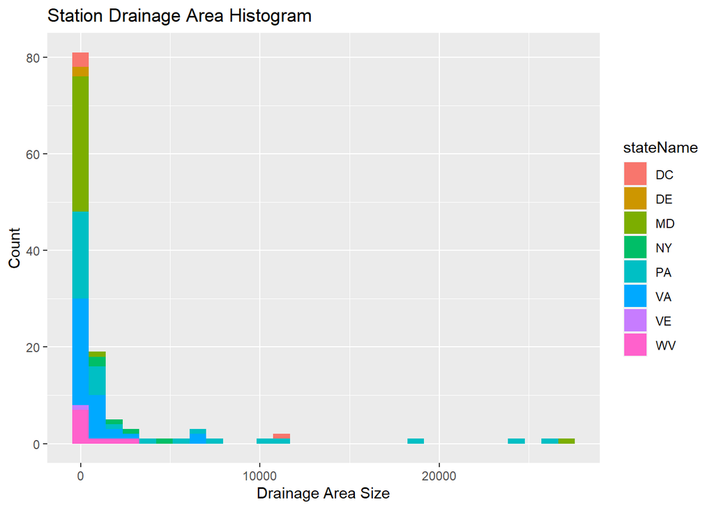

# Task 3: Write a function

### 3.1

```r
task3.1 <- function(numVect){
  isVec <- is.vector(numVect) #test if it is vector
  isNum <- is.numeric(numVect) #test if list is all numeric
  if(isVec == TRUE & isNum == TRUE) { #check that tests are both TRUE

    statList <- list(mean(numVect), median(numVect), max(numVect), min(numVect)) #create list with stat values

    sortVec <- sort(numVect) #sort vector from least to greatest

    result <- list(statList, sortVec) #combines desired data into one object for return function

    return(result) #return result

  } else{
    cat("Troubleshooting Errors\n") #provide information on why vector failed tests
    cat("Vector: ", isVec, "\n") #provides details on whether input data was vector or not
    cat("Numbers:", isNum, "\n") #provides detaisl on whether input data contained all numbers
  }
}

#Test 1
task3.1(c(1, 0, -1))
```

```
## [[1]]
## [[1]][[1]]
## [1] 0
##
## [[1]][[2]]
## [1] 0
##
## [[1]][[3]]
## [1] 1
##
## [[1]][[4]]
## [1] -1
##
##
## [[2]]
## [1] -1  0  1
```

```r
#Test 2
task3.1(c(10, 100, 1000))
```

```
## [[1]]
## [[1]][[1]]
## [1] 370
##
## [[1]][[2]]
## [1] 100
##
## [[1]][[3]]
## [1] 1000
##
## [[1]][[4]]
## [1] 10
##
##
## [[2]]
## [1]   10  100 1000
```

```r
#Test 3
task3.1(c(.1, .001, 1e8))
```

```
## [[1]]
## [[1]][[1]]
## [1] 33333333
##
## [[1]][[2]]
## [1] 0.1
##
## [[1]][[3]]
## [1] 1e+08
##
## [[1]][[4]]
## [1] 0.001
##
##
## [[2]]
## [1] 1e-03 1e-01 1e+08
```

```r
#Test 4
task3.1(c("a", "b", "c"))
```

```
## Troubleshooting Errors
## Vector:  TRUE
## Numbers: FALSE
```

# Task 4: Spatial analysis

### 4.1

```r
st_is_valid(d.counties) #was throwing an error so threw in to check
```

```
##   [1]  TRUE  TRUE  TRUE  TRUE  TRUE  TRUE  TRUE  TRUE  TRUE  TRUE  TRUE  TRUE
##  [13]  TRUE  TRUE  TRUE  TRUE  TRUE  TRUE  TRUE  TRUE  TRUE  TRUE  TRUE  TRUE
##  [25]  TRUE  TRUE  TRUE  TRUE  TRUE  TRUE  TRUE  TRUE  TRUE  TRUE  TRUE  TRUE
##  [37]  TRUE  TRUE  TRUE  TRUE  TRUE  TRUE  TRUE  TRUE  TRUE  TRUE  TRUE  TRUE
##  [49]  TRUE  TRUE  TRUE  TRUE  TRUE  TRUE  TRUE  TRUE  TRUE  TRUE  TRUE  TRUE
##  [61]  TRUE  TRUE  TRUE  TRUE  TRUE  TRUE  TRUE  TRUE  TRUE  TRUE  TRUE  TRUE
##  [73]  TRUE  TRUE  TRUE  TRUE  TRUE  TRUE  TRUE  TRUE  TRUE  TRUE  TRUE  TRUE
##  [85]  TRUE  TRUE  TRUE  TRUE  TRUE  TRUE  TRUE  TRUE  TRUE  TRUE  TRUE  TRUE
##  [97]  TRUE  TRUE  TRUE  TRUE  TRUE  TRUE  TRUE  TRUE  TRUE  TRUE  TRUE  TRUE
## [109]  TRUE  TRUE  TRUE  TRUE  TRUE  TRUE  TRUE  TRUE  TRUE  TRUE  TRUE  TRUE
## [121]  TRUE  TRUE  TRUE  TRUE  TRUE  TRUE  TRUE  TRUE  TRUE  TRUE  TRUE  TRUE
## [133]  TRUE  TRUE  TRUE  TRUE  TRUE  TRUE  TRUE  TRUE  TRUE  TRUE  TRUE  TRUE
## [145]  TRUE  TRUE  TRUE  TRUE  TRUE  TRUE  TRUE  TRUE  TRUE  TRUE  TRUE  TRUE
## [157]  TRUE  TRUE  TRUE  TRUE  TRUE  TRUE  TRUE  TRUE  TRUE  TRUE  TRUE  TRUE
## [169]  TRUE  TRUE  TRUE  TRUE  TRUE  TRUE  TRUE  TRUE  TRUE  TRUE  TRUE  TRUE
## [181]  TRUE  TRUE  TRUE  TRUE  TRUE  TRUE  TRUE  TRUE  TRUE  TRUE  TRUE  TRUE
## [193]  TRUE  TRUE  TRUE  TRUE  TRUE  TRUE  TRUE  TRUE  TRUE  TRUE  TRUE  TRUE
## [205]  TRUE FALSE  TRUE
```

```r
d.counties2 <- st_make_valid(d.counties) #make data valid for work
st_is_valid(d.counties2) #check success of make_valid
```

```
##   [1] TRUE TRUE TRUE TRUE TRUE TRUE TRUE TRUE TRUE TRUE TRUE TRUE TRUE TRUE TRUE
##  [16] TRUE TRUE TRUE TRUE TRUE TRUE TRUE TRUE TRUE TRUE TRUE TRUE TRUE TRUE TRUE
##  [31] TRUE TRUE TRUE TRUE TRUE TRUE TRUE TRUE TRUE TRUE TRUE TRUE TRUE TRUE TRUE
##  [46] TRUE TRUE TRUE TRUE TRUE TRUE TRUE TRUE TRUE TRUE TRUE TRUE TRUE TRUE TRUE
##  [61] TRUE TRUE TRUE TRUE TRUE TRUE TRUE TRUE TRUE TRUE TRUE TRUE TRUE TRUE TRUE
##  [76] TRUE TRUE TRUE TRUE TRUE TRUE TRUE TRUE TRUE TRUE TRUE TRUE TRUE TRUE TRUE
##  [91] TRUE TRUE TRUE TRUE TRUE TRUE TRUE TRUE TRUE TRUE TRUE TRUE TRUE TRUE TRUE
## [106] TRUE TRUE TRUE TRUE TRUE TRUE TRUE TRUE TRUE TRUE TRUE TRUE TRUE TRUE TRUE
## [121] TRUE TRUE TRUE TRUE TRUE TRUE TRUE TRUE TRUE TRUE TRUE TRUE TRUE TRUE TRUE
## [136] TRUE TRUE TRUE TRUE TRUE TRUE TRUE TRUE TRUE TRUE TRUE TRUE TRUE TRUE TRUE
## [151] TRUE TRUE TRUE TRUE TRUE TRUE TRUE TRUE TRUE TRUE TRUE TRUE TRUE TRUE TRUE
## [166] TRUE TRUE TRUE TRUE TRUE TRUE TRUE TRUE TRUE TRUE TRUE TRUE TRUE TRUE TRUE
## [181] TRUE TRUE TRUE TRUE TRUE TRUE TRUE TRUE TRUE TRUE TRUE TRUE TRUE TRUE TRUE
## [196] TRUE TRUE TRUE TRUE TRUE TRUE TRUE TRUE TRUE TRUE TRUE TRUE
```

```r
st_is_valid(d.stations) #check stations while at it
```

```
##   [1] TRUE TRUE TRUE TRUE TRUE TRUE TRUE TRUE TRUE TRUE TRUE TRUE TRUE TRUE TRUE
##  [16] TRUE TRUE TRUE TRUE TRUE TRUE TRUE TRUE TRUE TRUE TRUE TRUE TRUE TRUE TRUE
##  [31] TRUE TRUE TRUE TRUE TRUE TRUE TRUE TRUE TRUE TRUE TRUE TRUE TRUE TRUE TRUE
##  [46] TRUE TRUE TRUE TRUE TRUE TRUE TRUE TRUE TRUE TRUE TRUE TRUE TRUE TRUE TRUE
##  [61] TRUE TRUE TRUE TRUE TRUE TRUE TRUE TRUE TRUE TRUE TRUE TRUE TRUE TRUE TRUE
##  [76] TRUE TRUE TRUE TRUE TRUE TRUE TRUE TRUE TRUE TRUE TRUE TRUE TRUE TRUE TRUE
##  [91] TRUE TRUE TRUE TRUE TRUE TRUE TRUE TRUE TRUE TRUE TRUE TRUE TRUE TRUE TRUE
## [106] TRUE TRUE TRUE TRUE TRUE TRUE TRUE TRUE TRUE TRUE TRUE TRUE TRUE TRUE TRUE
## [121] TRUE TRUE
```

```r
d.stations2 <- sf::st_intersection(d.stations, d.counties2) #intersect so stations get counties df info
task4.1 <- d.stations2 %>% as_tibble() %>% #count number of features per STATEFP10
  count(STATEFP10)

task4.1
```

```
## # A tibble: 7 x 2
##   STATEFP10     n
##   <chr>     <int>
## 1 10            2
## 2 11            3
## 3 24           31
## 4 36            4
## 5 42           35
## 6 51           37
## 7 54           10
```

### 4.2

```r
# NY FIPS = 36
task4.2 <- d.counties2 %>% filter(STATEFP10 == 36) %>% # select counties in NY
  mutate(polyArea = st_area(geometry)) %>%  #calculate area of counties
  as_tibble() %>% #convert to tibble
  summarize(mean(polyArea)) #calculate mean

task4.2
```

```
## # A tibble: 1 x 1
##   `mean(polyArea)`
##              [m^2]
## 1      2088695951.
```

### 4.3

```r
meanDrain <- d.stations2 %>% as_tibble() %>% #d.stations2 was updated in task 4.1 so no spatial ops needed
  group_by(STATEFP10) %>% #group by state
  summarize(mean(Drainage_A))

maxPos <- which.max(meanDrain$`mean(Drainage_A)`) #find the rowwhere the largest mean drainage is

task4.3 <- meanDrain[maxPos,] #subset tibble

task4.3
```

```
## # A tibble: 1 x 2
##   STATEFP10 `mean(Drainage_A)`
##   <chr>                  <dbl>
## 1 42                     3584.
```

# Questions

1. In using the intersection functions, are the following two statements equivalent? If not, explain how. Be sure to think about BOTH the spatial data structures AND the attribute data. Would your answer be different if we were using different types of data?

```
 sf::st_intersection(d.stations, del.counties)
 sf::st_intersection(del.counties, d.stations)
```

These two statements are not equivalent. Both result in a sf object with POINT geometry, as the stations represent the geometry where both overlap (the st_intersection function appears to do this because points are not 2D). The difference comes from when both sf objects in the function have the same column name, in which the column from the first is retained in the resulting geometry df.

See the following chunk for proof of same geometry type.

```
## Geometry set for 122 features
## Geometry type: POINT
## Dimension:     XY
## Bounding box:  xmin: -79.897 ymin: 37.22516 xmax: -75.40611 ymax: 42.37779
## Geodetic CRS:  WGS 84
## First 5 geometries:
```

```
## POINT (-78.14084 40.61251)
```

```
## POINT (-76.61912 40.95815)
```

```
## POINT (-76.68056 41.06167)
```

```
## POINT (-78.26529 40.21592)
```

```
## POINT (-75.89464 41.55842)
```

```
## Geometry set for 122 features
## Geometry type: POINT
## Dimension:     XY
## Bounding box:  xmin: -79.897 ymin: 37.22516 xmax: -75.40611 ymax: 42.37779
## Geodetic CRS:  WGS 84
## First 5 geometries:
```

```
## POINT (-75.56186 38.72834)
```

```
## POINT (-75.67311 38.8497)
```

```
## POINT (-75.78581 38.9972)
```

```
## POINT (-75.94306 38.96681)
```

```
## POINT (-75.82559 39.66759)
```

2. What did you find challenging in this lab? What was new?

I found the df/tibble manipulations the hardest. It was confusing at times to do a group_by then mutate or filter the data. Also, filter and select seem equivalent to me at times and I forget which one to use. Otherwise, much of the spatial details makes sense as other pro- grams and languages use similar methods.

3. What types of activities would you like to see in labs this semester?

I would enjoy a lab where we perform spatial analysis and then be given an audience or to that we need to produce a report-style document with figures and maps. I feel this would be a chance to try a real world application of the Markdown.